Biostatistics

**Chapters**

**On this page**

# Power Analysis

## 1. Statistical Power

When we do hypothesis testing, a low p-value gives us grounds to reject the Null hypothesis. Recall, a p-value is the probability of seeing data as extreme as (or more extreme than) what you observed, assuming the null hypothesis is true. But how do we know if our study was actually capable of finding an effect in the first place? That is where the concept of statistical power comes in. Power is the probability that our test will successfully detect a real effect when one truly exists—in other words, the probability of correctly rejecting a false Null hypothesis.

Having clarity on statistical power is important because in real-world experiments, there can be errors when we are testing a hypothesis. For example, we can accidentally get a low p-value (making us reject the Null hypothesis) when actually there is no real effect. This, as we know, is called a **Type I error**. The probability of having a Type I error is denoted by alpha ($\alpha$).On the other hand, there is a possibility that a real effect exists, but our test fails to capture it—this is a **Type II error**. The probability of having a Type II error is denoted by beta ($\beta$).

With power analysis, we want to estimate the probability of successfully **catching an effect** when it is there. Notice this is the exact opposite (the complement) of beta (**missing an effect** when it is there). So, mathematically, $Power = 1 - \beta$.

Power tells you how good your detector is at detecting a real effect. For example, 80% power means that, assuming the specified effect and other assumptions are correct, the study has an 80% chance of detecting that effect at the chosen significance level.

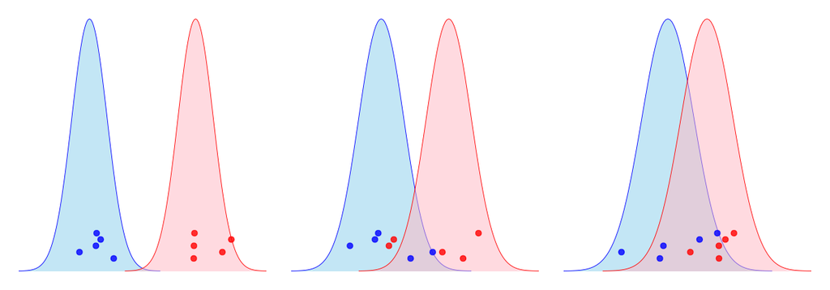

Comparison of normal distributions with little vs. greater overlap. Statistical power decreases from left to right.

As shown in the Figure 1 , when there is less overlap between the two distribution then there is a very low probability that the sample data could be from a single distribution. In other words, we have high confidence that the differences we a seeing are real differences. This mean we have high statistical power. On the other hand, when we look a the right-most graph, we can imagine that these points could be from a single distribution since there is high overlap between the two distribution. In this case, theoretically, we can have data points (blue and red) that are exclusively in the non-overlapping regions of the distributions. If that happens then the analysis will indicate that there is significant difference between the two groups. However, the probability of that happening is rather low. So, we can say the in the right-most case, the statistical power is low.

## 2. Factors that affect power

To have high confidence in the outcomes of a study, multitude of factors make a synergistic contribution. For instance, one somewhat obvious factor that we can think of is sample size, that is, the more samples we have, the greater will be the confidence we will have in our analysis. That is because when we compare different groups with each group having a large number of samples, we expect that the real differences between the groups will be accurately captured. Similarly, another factor that can boost confidence is less variability within the samples in each group. Let's say if we are comparing 2 or more groups and the samples in each group show less variance, then the differences that we see between the groups are more likely to be real. Apart from this effect, size and the probability of Type I error ($\alpha$) that we choose for our study directly influence the statistical power. Table lists the factors and gives a brief description on how they affect the statistical power.

Factors affecting satistical power.

| Factor | Description |
| --- | --- |
| **Effect Size** | The magnitude of the difference or relationship between groups. Larger differences between groups are much easier to detect. |
| **Sample Size** | The total number of observations or participants in the study. More data points reduce standard error and provide a sharper estimate. |
| **Significance Level ($\alpha$)** | The threshold set for a statistically significant result (commonly $0.05$). A higher threshold makes it easier to reject the null hypothesis (though it raises false positive risks). |
| **Data Variability ($\sigma$)** | The amount of scatter or noise present within your population data. Tighter distributions make the underlying signal stand out clearly against background noise. |

## 3. Study design

```r
library(pwr)
library(knitr)
library(kableExtra)
library(IRdisplay)

# Define Trial Parameters
delta <- 0.5       # Target mean difference in HbA1c (%)
sigma <- 1.2       # Estimated standard deviation (%)
alpha_level <- 0.05 # Significance level (Type I error)
target_power <- 0.80 # Desired statistical power (1 - Type II error)
dropout_rate <- 0.15 # Anticipated patient dropout / attrition rate

# Calculate Cohen's d (Standardized Effect Size)
# d = difference / standard deviation
cohens_d <- delta / sigma
cat("Calculated Cohen's d:", round(cohens_d, 4), "\n")

# Perform Power Analysis for a Two-Sample t-test
power_result <- pwr.t.test(
  d = cohens_d,
  sig.level = alpha_level,
  power = target_power,
  type = "two.sample",
  alternative = "two.sided"
)

print(power_result)

# Extract and calculate sample sizes
n_per_arm <- ceiling(power_result$n)
total_evaluable <- n_per_arm * 2

# Adjust for Attrition
total_recruited <- ceiling(total_evaluable / (1 - dropout_rate))
n_per_arm_recruited <- ceiling(total_recruited / 2)

sample_summary <- data.frame(
  Stage = c("Evaluable", "Evaluable", "Recruitment (15% Attrition)", "Recruitment (15% Attrition)"),
  Parameter = c(
    "Required per arm",
    "Total patients needed",
    "Total patients to recruit",
    "Recruit per arm"
  ),
  Sample_Size = c(
    n_per_arm,
    total_evaluable,
    total_recruited,
    n_per_arm_recruited
  )
)

html_table <- sample_summary %>%
  kable(format = "html") %>%
  kable_styling(
    bootstrap_options = c("bordered", "hover", "condensed"),
    full_width = FALSE
  )

display_html(paste(html_table, collapse = "\n"))
```

```
Calculated Cohen's d: 0.4167

     Two-sample t test power calculation

              n = 91.38922
              d = 0.4166667
      sig.level = 0.05
          power = 0.8
    alternative = two.sided

NOTE: n is number in *each* group
```

| Stage | Parameter | Sample_Size |
| --- | --- | --- |
| Evaluable | Required per arm | 92 |
| Evaluable | Total patients needed | 184 |
| Recruitment (15% Attrition) | Total patients to recruit | 217 |
| Recruitment (15% Attrition) | Recruit per arm | 109 |

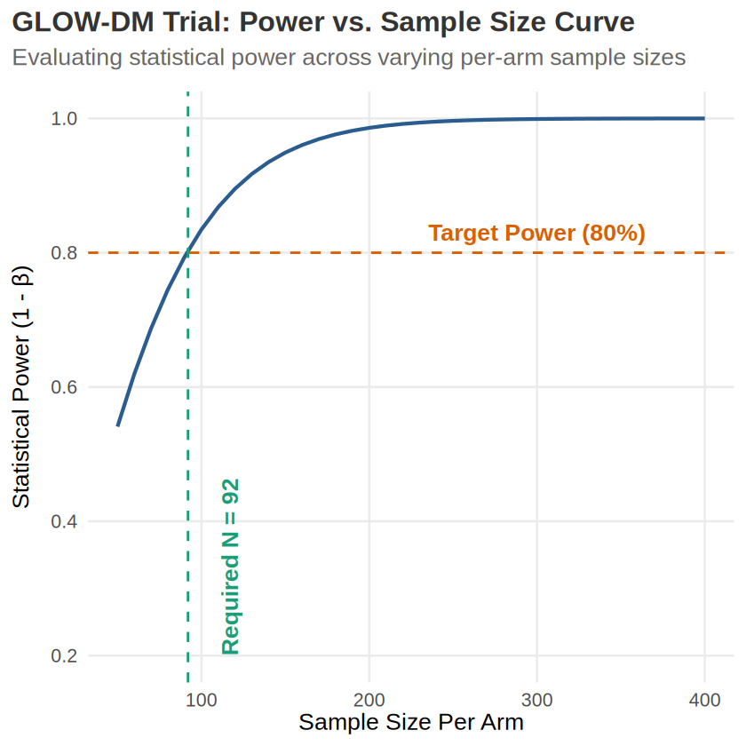

```r
# Generating a Power Curve for Visualization
sample_sizes <- seq(50, 400, by = 10)
calculated_power <- sapply(sample_sizes, function(n) {
  pwr.t.test(d = cohens_d, n = n, sig.level = alpha_level, type = "two.sample")$power
})

# Plotting the curve
library(ggplot2)

# Prepare data for ggplot
plot_data <- data.frame(
  sample_size = sample_sizes,
  power = calculated_power
)

# Create the ggplot visualization
ggplot(plot_data, aes(x = sample_size, y = power)) +
  # Power curve line
  geom_line(color = "#2b5c8f", linewidth = 1.2) +

  # Threshold lines for 80% power and required sample size
  geom_hline(yintercept = target_power, color = "#d95f02", linetype = "dashed", linewidth = 0.8) +
  geom_vline(xintercept = n_per_arm, color = "#1b9e77", linetype = "dashed", linewidth = 0.8) +

  # Annotations to make the plot self-explanatory for students
  annotate("text", x = max(plot_data$sample_size) * 0.75, y = target_power + 0.03,
           label = paste0("Target Power (", target_power * 100, "%)"), color = "#d95f02", fontface = "bold") +
  annotate("text", x = n_per_arm + 25, y = 0.2,
           label = paste0("Required N = ", n_per_arm), color = "#1b9e77", fontface = "bold", angle = 90, hjust=0) +

  # Labels and clean theme
  labs(
    title = "GLOW-DM Trial: Power vs. Sample Size Curve",
    subtitle = "Evaluating statistical power across varying per-arm sample sizes",
    x = "Sample Size Per Arm",
    y = expression("Statistical Power (1 - " * beta * ")")
  ) +
  theme_minimal(base_size = 16) +
  theme(
    plot.title = element_text(face = "bold", color = "#333333",hjust = 0),
    plot.title.position = "plot",
    plot.subtitle = element_text(color = "#666666", margin = margin(b = 15)),
    panel.grid.minor = element_blank()
  )
```

## 4. Importance of Power Analysis

Although we know that increasing sample size will generally increase the power. However, because of a variety of constraints, we cannot keep on increasing the sample size. Because for various studies, like e.g. clinical trials, each sample has an associated cost, we have to be mindful when we decide on the number of samples we are going to test in those trials. That's where power analysis is an immensely valuable tool for effective study design. Apart from the monetary considerations, we need to be cognizant of ethical implications as well. Which means, power analysis will tell us the right amount of sample size for our study, ensuring that we do not end up testing the intended therapy on an unreasonable number of patients. Besides this, many regulatory agencies now frequently require the details of the power analysis in the study design.

## 5. Exercise

Assume the following study-design parameters (based on the published [SPRINT trial design](https://www.nejm.org/doi/full/10.1056/NEJMoa1511939)):

- The trial has two parallel treatment groups with 1:1 randomization.
- The expected hazard ratio for the primary outcome is 0.80. That is, at any given point during follow-up, the instantaneous risk (hazard) of experiencing the primary outcome is expected to be 20% lower in the treatment group than in the control group.
- The expected annual event hazard in the control group is 0.022 (2.2% per year).
- The expected annual loss-to-follow-up rate is 0.02 (2% per year).
- Participants are recruited uniformly over approximately 2 years and the total study duration is 6 years. The minimum follow-up is approximately 3 years and 10 months.
- The statistical test is two-sided with significance level of α = 0.05.
- The desired statistical power is 80%.
- The sample-size calculation should use the Lachin–Foulkes method.

**Hint:** Use `gsDesign` package.

**Show Answer**

```r
library(gsDesign)

# SPRINT design assumptions
lambdaC <- 0.022             # control event hazard/year
hr <- 0.80                   # treatment/control hazard ratio
eta <- -log(0.98)            # dropout hazard/year

R <- 2                       # recruitment duration, years
T <- 6                       # total study duration, years

minfup <- 3 + 10/12          # minimum follow-up = 3 years 10 months

ratio <- 1                   # 1:1 randomization

alpha <- 0.05                # two-sided alpha
beta <- 0.2                  # 80% power

# Lachin-Foulkes sample-size calculation
sSurv_summary <- nSurv(
  lambdaC = lambdaC,
  hr = hr,
  eta = eta,
  gamma = 1,
  R = R,
  T = T,
  minfup = minfup,
  ratio = ratio,
  alpha = alpha,
  beta = beta,
  sided = 2,
  method = "LachinFoulkes"
)

# Show results
sSurv_summary
```

[output not shown]